# Organizing with Unix

Unix is the operating system of choice in data science. We will introduce you to the approach and way of thinking [AN: “approach and way of thinking”" of what? Unix?] using an example: how to keep a data analysis project organized. We will learn some of the most commonly used commands along the way. However, we won’t go into the details here. We highly encourage you to learn more, especially when you find yourself using the mouse too much or performing a repetitive task often. In those cases, there is probably a more efficient way to do it in Unix. Here are some basic courses to get you started:

- https://www.codecademy.com/learn/learn-the-command-line
- https://www.edx.org/course/introduction-linux-linuxfoundationx-lfs101x-1
- https://www.coursera.org/learn/unix

There are many other courses [AN: “books”? and if you make this change, perhaps change the link] that are also very informative [reference books](https://www.quora.com/Which-are-the-best-Unix-Linux-reference-books).

When searching for Unix resources, keep in mind that other terms used to describe what we will learn here are *Linux*, *the shell* and *the command line*. Basically, what we are learning is a series of commands and a way of thinking that facilitates the organization of files without using the mouse.

To serve as motivation, we are going to start constructing a directory using Unix tools and RStudio.

## The Terminal

*The Terminal* is our window into the Unix world. Instead of clicking, dragging and dropping to organize our files and folders, we will be typing commands into The Terminal. We will do this in The Terminal, similar to how we type commands into the R console, but instead of generating plots and statistical summaries, we will be organizing files on our system.

We have already described how we can access a terminal using RStudio, namely by going to *Tools* then *Terminal* then *New Terminal*. But often we want access to The Terminal, but do not need RStudio. We already described how to access The Terminal on the Mac by opening the application in the Utilities folder:

[figure not shown]

[figure not shown]

[figure not shown]

You can also use the Spotlight feature on the Mac by typing command-spacebar, then type *Terminal*.

On Windows, assuming you’ve installed Git Bash, we can also access a terminal without RStudio by running the Git Bash program:

[figure not shown]

[figure not shown]

Once you have a terminal open, you can start typing commands. You should see a blinking cursor at the spot where what you type will show up. This position is called the *command line*. Once you type something and hit enter on Windows or return on the Mac, Unix will try to execute this command. If you want to try out an example, type this command into your command line:

```bash
echo "hello world"
```

The command `echo` is similar to `cat` in R. Executing this line should print out `hello world`, then return back to the command line. Notice that you can’t use the mouse to move around in the terminal. You have to use the keyboard. To go back to a command you previously typed, you can use the up arrow.

Above we included a chunk of code showing Unix commands in the same way we have previously shown R commands. We will make sure to distinguish when the command is meant for R and when it is meant for Unix.

## The Filesystem

We refer to all the files, folder, and programs on your computer as *the filesystem*. Keep in mind that folders and programs are also files, but this is a technicality we rarely think about and ignore in this book. We will focus on files and folders for now and discuss programs, or *executables*, in a later section.

### Directories and subdirectories

The first concept you need to grasp to become a Unix user is how your file system is organized. You should think of it as a series of nested folders each containing files, folders, and executables.

Here is a visual representation of the structure we are describing:

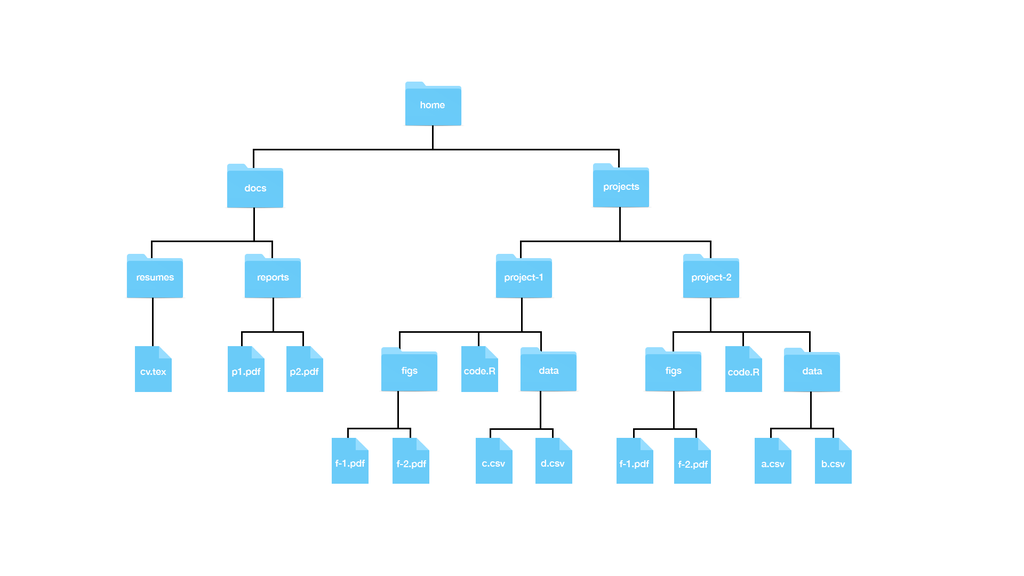

In Unix, we refer to folders as *directories*. Directories that are inside other directories are often referred to as *subdirectories*. So, for example, in the figure above, the directory *docs* has two subdirectories: *reports* and *resumes*, and *docs* is a subdirectory of *home*.

### The home directory

The *home* directory is where all your stuff is kept. In the figure above, the directory called *home* represents your home directory but that is rarely the name used. On your system, the name of your home directory is likely the same as your username on that system. Below is an example on Windows showing a home directory, in this case, named *rafa*:

[figure not shown]

Here is an example from a Mac:

[figure not shown]

Now, look back at the figure showing a filesystem. Suppose you are using a point-and-click system and you want to remove the file *cv.tex*. Imagine that on your screen you can see the *home* directory. To erase this file, you would double click on the *home* directory, then *docs*, the *resumes*, and then drag *cv.tex* to the trash. Here you are experiencing the hierarchical nature of the system: *cv.tex* is a file inside the *resumes* directory, which is a subdirectory inside the *docs* directory, which is a subdirectory of the *home* directory.

Now suppose you can’t see your home directory on your screen. You would somehow need to make it appear on your screen. One way to do this is to navigate from what is called the *root* directory all the way to your home directory. Any file system will have what is called a *root* directory which is the directory that contains all directories. The *home* directory shown in the figure above will usually be two or more levels from the root. On Windows, you will have a structure like this:

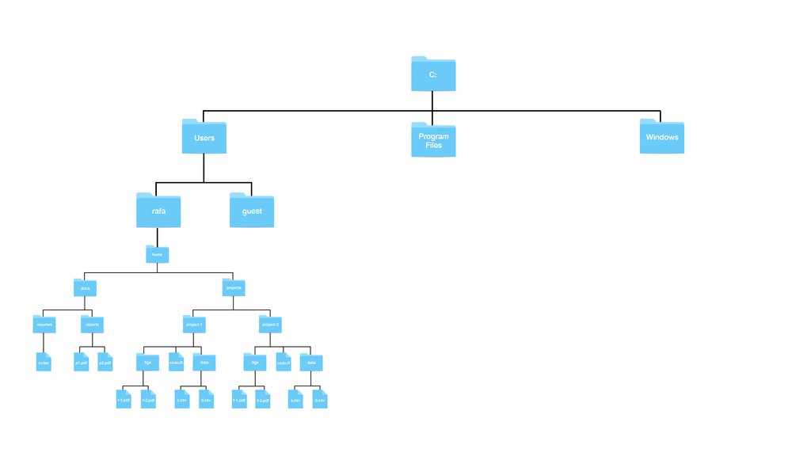

while on the Mac, it will be like this:

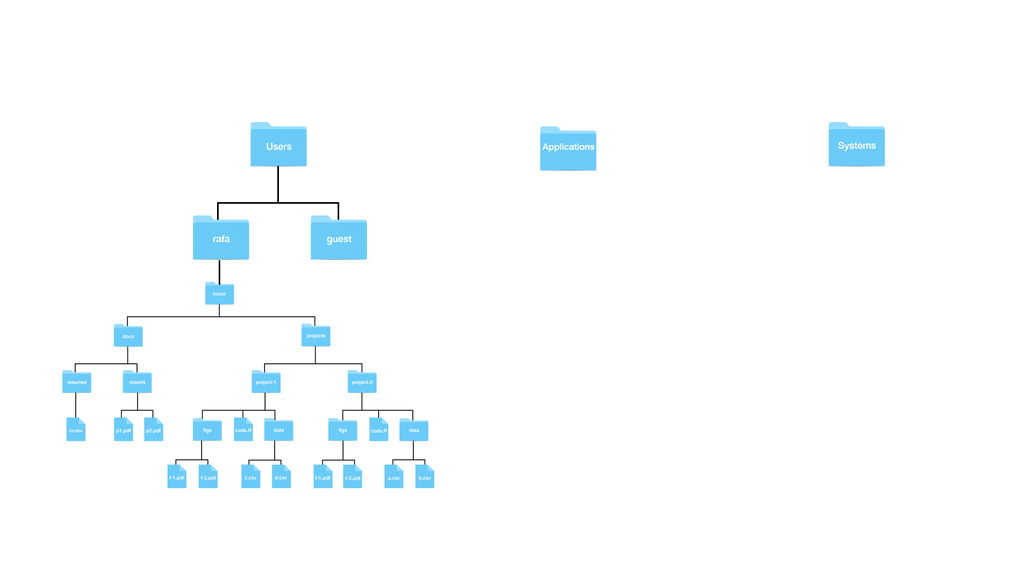

**Note for Windows User:** The typical R installation will make your `Documents` your home directory in R. This will likely be different from your home directory in Git Bash. Generally, when we discuss home directories, we refer to the Unix home directory which for Windows, in this book, is Git Bash.

### Working directory

The concept of a *current location* is part of the point-and-click experience: at any given moment we are *in a folder* and see the content of that folder. As you search for a file, as we did above, you are experiencing the concept of a current location: once you double click on a directory, you change locations and are now *in that folder*, as opposed to the folder you were in before.

In Unix, we don’t have the same visual cues, but the concept of a *current location* is indispensable. We refer to this as the *working directory*. Each terminal window you have open has a working directory associated with it.

How do we know what is our working directory? The first command we learn is `pwd`, which stands for *print working directory*. This command returns the working directory.

Open a terminal and type:

```bash
pwd
```

We do not show the result of running this command because it will be quite different on your system compared to others. If you open a terminal and type `pwd` as your first command, you should see something like `/Users/yourusername` on a Mac or something like `/c/Users/yourusername` on Windows. The character string returned by calling `pwd` represents your working directory. When we first open a terminal, it will start in our home directory so in this case the working directory is the home directory.

Notice that the forward slashes `/` in the strings above separate directories. So, for example, the location `/c/Users/rafa` implies that our working directory is called `rafa` and it is a subdirectory of `Users`, which is a subdirectory of `c`, which is a subdirectory of the root directory. The root directory is therefore represented by just a forward slash: `/`.

### Paths

We refer to the string returned by `pwd` as the *full path* of the working directory. The name comes from the fact that this string spells out the *path* you need to follow to get to the directory in question from the root directory. Every directory has a full path. Later, we will learn about *relative paths*, which tell us how to get to a directory from the working directory.

In Unix we use the shorthand `~` as a nickname for your home directory. So, for example, if `docs` in the path to a directory [AN: change “in” to “is”?] in your home directory, *docs* can be written like this `~/docs`.

Most terminals will show the path to your working directory right on the command line. If you are using default settings and open a terminal on the Mac, you will see that right at the command line you have something like `computername:~ username` with `~` representing your working directory, which in this example is the home directory `~`. The same is true for the Git Bash terminal where you will see something like `username@computername MINGW64 ~`, with the working directory at the end. When we change directories, we will see this change on both Macs and Windows.

## Unix commands

We will now learn a series of Unix commands that will permit us to prepare a directory for a data science project. We also provide examples of commands that, if you type into your terminal, will return an error. This is because we are assuming the file system in the cartoon above. Your file system is different. In the next section, we will provide examples that you can type in.

### `ls`: Listing directory content

In a point-and-click system, we know what is in a directory because we see it. In the terminal, we do not see the icons. Instead, we use the command `ls` to list the directory content.

To see the content of you home directory, open a terminal and type:

```bash
ls
```

We will see more examples soon.

### `mkdir` and `rmdir`: make and remove a directory

When we are preparing for a data science project, we will need to create directories. In Unix, we can do this with the command `mkdir`, which stands for *make directory*.

Because you will soon be working on several projects, we highly recommend creating a directory called *projects* in your home directory.

You can try this particular example on your system. Open a terminal and type:

```bash
mkdir projects
```

If you do this correctly, nothing will happen: no news is good news. If the directory already exists, you will get an error message and the existing directory will remain untouched.

To confirm that you created these directories, you can list the directories:

```bash
ls
```

You should see the directories we just created listed. Perhaps you can also see many other directories that come pre-installed on your computer.

For illustrative purposes, let’s make a few more directories. You can list more than one directory name like this:

```bash
mkdir docs teaching
```

You can check to see if the three directories were created:

```bash
ls
```

If you made a mistake and need to remove the directory, you can use the command `rmdir` to remove it.

```bash
mkdir junk
rmdir junk
```

This will remove the directory as long as it is empty. If it is not empty, you will get an error message and the directory will remain untouched. To remove directories that are not empty, we we will learn about the command `rm` later.

### `cd`: Navigating the filesystem by changing directories

Next we want to create directories inside directories that we have already created. We also want to avoid pointing and clicking our way through the filesystem. We therefore will explain how do this in Unix, using the command line.

Suppose we open a terminal. Our working directory is our home directory. We want to change our working directory to `projects`. We do this using the `cd` command, which stands for *change directory*:

```bash
cd projects
```

To check that the working directory changed, we can use a command we previously learned:

```bash
pwd
```

Our working directory should now be `~/projects`. Note that on your computer the home directory `~` will be spelled out to something like `/c/Users/yourusername`).

**Important Pro Tip**: In Unix you can auto-complete by hitting tab. This means that we can type `cd d` then hit tab. Unix will either auto-complete if `docs` is the only directory/file starting with `d` or show you the options. Try it out! Using Unix without auto-complete will make it unbearable.

When using `cd`, we can either type a full path, which will start with `/` or `~`, or a *relative path*. In the example above, in which we typed `cd projects`, we used a relative path. If the path you type does not start with `/` or `~`, Unix will assume you are typing a relative path, meaning that it will look for the directory in your current working directory. So something like this will give you an error:

```bash
cd Users
```

because there is no `Users` directory in your working directory.

Now suppose we want to move back to the directory in which `projects` is a subdirectory, referred to as the *parent directory*. We could use the full path of the parent directory, but Unix provides a shortcut for this: the parent directory of the working directory is represented with two dots: `..`. So to move back we simply type:

```bash
cd ..
```

You should now be back in your home directory which you can confirm using `pwd`.

Because we can use full paths with `cd`, the following command:

```bash
cd ~
```

will always take us back to the home directory, no matter where we are in the filesystem.

The working directory also has a nickname and it is a single `.`. So if you type:

```bash
cd .
```

You will not move. Although this particular use of `.` is not useful, this nickname does come in handy sometimes. The reasons are not relevant for this section, but you should still be aware of this fact.

In summary, we have learned that when using `cd` we either stay put, move to a new directory using the desired directories name, or move back to the parent directory using `..`.

Now when typing directory names, we can concatenate directories with the forward-slashes. So if we want a command that takes us to the `projects` directory no matter where we are in the filesystem, we can type:

```bash
cd ~/projects
```

which is equivalent to writing the entire path out. For example, in Windows we would write something like

```bash
cd /c/Users/yourusername/projects
```

The last two commands are equivalent and in both cases we are typing the full path.

We can also concatenate directory names for relative paths. So, for instance, if we want to move back to the parent directory of the parent directory of the working directory [AN: remove one “parent directory” or are both correct?], we can type:

```bash
cd ../..
```

A couple of final tips related to the `cd` command. First, you can go back to whatever directory you just left by typing:

```bash
cd -
```

This can be useful if you type a very long path and then realize you want to go back to where you were, and that too has a very long path.

Second, if you just type:

```bash
cd
```

you will be returned to your home directory.

## Some examples

Let’s explore some examples of using `cd`. To help visualize, we will show the graphical representation of our file system vertically:

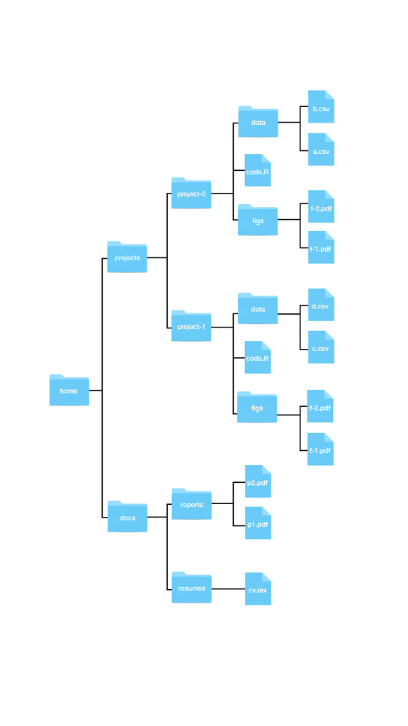

Suppose our working directory is `~/projects` and we want to move to `figs` in `project-1`.

Here it convenient to use relative paths:

```bash
cd project-1/figs
```

Now suppose our working directory is `~/projects` and we want to move to `reports` in `docs`, how can we do this?

One way is to use relative paths:

```bash
cd ../docs/reports
```

Another is to use the full path:

```bash
cd ~/docs/reports
```

If trying this out on your system, remember auto-complete.

Let’s examine one more example. Suppose we are in `~/projects/project-1/figs` and want to change to `~/projects/project-2`. Again, there are two ways.

With relative paths:

```bash
cd ../../proejct-2
```

and with full paths:

```bash
cd ~/projects/project-2
```

### `mv`: moving files

In a point-and-click system, we move files from one directory to another by dragging and dropping. In Unix, we use the `mv` command.

**Warning**: `mv` will not ask “are you sure?” if your move results in overwriting a file.

Now that you know how to use full and relative paths, using `mv` is relatively straightforward. The general form is:

```bash
mv path_to_file path_to_destination_directory
```

So, for example, if we want to move the file `cv.tex` from `resumes` to `reports`, you could use the full paths like this:

```bash
mv ~/docs/resumes/cv.tex ~/docs/reports/
```

You can also use relative paths. So you could do this:

```bash
cd ~/docs/resumes
mv cv.tex ../reports/
```

or this:

```bash
cd ~/docs/reports/
mv ../cv.tex ./
```

Notice that, in the last one, we used the working directory shortcut `.` to give a relative path as the destination directory.

We can also use `mv` to change the name of a file. To do this, instead of the second argument being the destination directory, it also includes a filename. So, for example, to change the name from `cv.tex` to `resume.tex`, we simply type:

```bash
cd ~/docs/resumes
mv cv.tex resume.tex
```

We can also combine the move and a rename. For example:

```bash
cd ~/docs/resumes
mv cv.tex ../reports/resume.tex
```

And we can move entire directories. So to move the `resumes` directory into `reports`, we do as follows:

```bash
mv ~/docs/resumes ~/docs/reports/
```

It is important to add the last `/` to make it clear you do not want to rename the `resumes` directory to `reports`, but rather move into `reports`.

### `cp`: copying files

The command `cp` behaves similar to `mv` except instead of moving, we copy the file, meaning that the original file stays untouched.

So in all the `mv` examples above, you can switch `mv` to `cp` and they will copy instead of move with one exception. We can’t copy entire directories without learning about arguments.

### `rm`: removing files

In point-and-click systems, we remove files by dragging and dropping them into the trash or using some special click on the mouse. In Unix, we use the `rm` command.

**Warning**: Unlike throwing files into the trash, `rm` is permanent so be careful.

The general way it works is like this:

```bash
rm filename
```

You can actually list files as well like this:

```bash
rm filename-1 filename-2 filename-3
```

You can use full or relative paths. To remove directories, you will have to learn about arguments which we do later.

## `less`: looking at a file

Often you want to quickly look at the content of a file. If this file is a text, the quickest way to do is by using the command `less`. To look a the command `cv.tex`, you do this: [AN: review that last sent]

```bash
cd ~/docs/resumes
less cv.tex
```

To exit the viewer, you type `q`. If the files are long, you can use the arrow keys to move up and down. There are many other keyboard commands you can use within `less` to, for example, search or jump pages. You will learn more about this in a later section.

If you are wondering why the command is called `less`, it is because the original was called `more`, as in “show me more of this file”. The second version was called `less` because of the saying “less is more”.

## Preparing for a data science project

We are now ready to prepare a directory for a project. You should start by creating a directory where you will keep all your projects. We recommend a directory called *projects* in your home directory. To do this you would type:

```bash
cd ~
mkdir projects
```

Open a terminal and make sure you are in the home directory:

```bash
cd ~
```

Now run the following commands to create the directory structure we want. At the end, we use `ls` and `pwd` to confirm we have generated the correct directories in the correct working directory:

```bash
cd projects
mkdir murders
cd murders
mkdir data rdas
ls
pwd
```

Note that the full path of our `murders` dataset is `~/projects/murders`.

So if we open a new terminal and want to navigate into that directory we type:

```bash
cd projects/murders
```

In RStudio when you start a new project, you can pick *Exsting Directory* instead of *New directory*:

[figure not shown]

and write the full path of the `murders` directory:

[figure not shown]

Once you do this, you will see the `rdas` and `data` directories you created in the *Files* tab.

[figure not shown]

Keep in mind that when we are in this project, our default working directory will be `~/projects/murders`. You can confirm this by typing `getwd()` into your R session. This is important because it will help us organize the code when we need to write file paths.

**Pro tip: Always use relative paths in data science projects, and relative to a default working directory.** [AN: “relative to a default” ok?]

The problem with using full paths is that your code is unlikely to work on filesystems other that yours since the directory structures will be different. This includes using the home directory `~` as part of your path.

Let’s now write a script that downloads a file into the data directory. We will call this file `download-data.R`.

The content of this file will be:

```r
url <- "https://raw.githubusercontent.com/rafalab/dslabs/master/inst/extdata/murders.csv"
dest_file <- "data/murders.csv"
download.file(url, destfile = dest_file)
```

Notice that we are using the relative path `data/muders.csv`.

Run this code in R and you will see that a file is added to the `data` directory.

Now we are ready to write a script to read this data and prepare a table that we can use for analysis. Call the file `wrangle-data.R`. The content of this file will be:

```r
library(tidyverse)
murders <- read_csv("data/murders.csv")
murders <-murders %>% mutate(region = factor(region),
                             rate = total / population * 10^5)
save(murders, file = "rdas/murders.rda")
```

Again note we use relative paths exclusively.

In this file, we introduce a command we have not seen: `save`. The `save` command in R saves objects into what is called an *rda file*, *rda* stands for R data. We recommend using the `.rda` suffix on files saving R objects. You will see that `.RData` is also used.

Now we are ready to write the analysis file. Let’s call it `analysis.R`. The content should be the following:

```r
library(tidyverse)
load("rdas/murders.rda")

murders %>% mutate(abb = reorder(abb, rate)) %>%
  ggplot(aes(abb, rate)) +
  geom_bar(width = 0.5, stat = "identity", color = "black") +
  coord_flip()
```

```bash
mkdir figs
```

and then you can add the line:

```r
ggsave("figs/barplot.png")
```

to our script. If you run the script now, a png file will be saved into the `figs` directory. If we wanted to copy that file to some other directory where we are developing a presentation, we can avoid using the mouse by using the `cp` command in our terminal.

You now have a self-contained analysis in one directory. One final recommendation is to create a `README.txt` file describing what each of these files does for the benefit of others reading your code, including your future self. This would not be a script but just some notes. One of the options provided when opening a new file in RStudio is a text file. You can save something like this into the text file:

[output not shown]

[AN: check that above notes are complete. anaylysis.R seems to be incomplete] If you now type `pwd`, you will see you are in `~/projects/murders` with `~` representing the home directory.

You have now successfully used Unix and RStudio to create a directory for a project. When a new project comes your way, you can simply `cd` back to `project` directory, create a new directory and start a new project.

You can see a version of this project, organized with Unix directories, on [GitHub](https://github.com/rairizarry/murders). You can download a copy to your computer by using the `git clone` command on your terminal. This command will create a directory called `murders` on your working directory so be careful where you call it from.

```r
git clone https://github.com/rairizarry/murders.git
```